# 3dasm_Lecture3 slides

[figure not shown]

## Data-driven Design and Analyses of Structures and Materials (3dasm)

## Lecture 3

### Miguel A. Bessa | M.A.Bessa@tudelft.nl | Associate Professor

## **OPTION 1**. Run this notebook **locally in your computer**:

1. Confirm that you have the 3dasm conda environment (see Lecture 1).
2. Go to the 3dasm_course folder in your computer and pull the last updates of the [repository](https://github.com/bessagroup/3dasm_course):

   ```
   git pull
   ```

3. Open command window and load jupyter notebook (it will open in your internet browser):

   ```
   conda activate 3dasm
   jupyter notebook
   ```

4. Open notebook of this Lecture.

## **OPTION 2**. Use **Google's Colab** (no installation required, but times out if idle):

1. go to https://colab.research.google.com
2. login
3. File > Open notebook
4. click on Github (no need to login or authorize anything)
5. paste the git link: https://github.com/bessagroup/3dasm_course
6. click search and then click on the notebook for this Lecture.

## Outline for today

- Probability: multivariate models
  - Introduction to joint pdfs
  - Marginal pdfs
  - Conditional pdfs

**Reading material**: This notebook + Chapter 3 (until Section 3.3)

## Consider an even simpler car distance problem

[figure not shown]

For now, let's focus on the case where every driver is going at the same velocity $x=75$ m/s.

Then, the governing model is even simpler:

${\color{red}y} = {\color{blue}z}\cdot 75 + 0.1\cdot 75^2 = 75 {\color{blue}z} + 562.5$

- ${\color{red}y}$ is the **output**: the car stopping distance (in meters)
- ${\color{blue}z}$ is a hidden variable: an rv representing the driver's reaction time (in seconds)

where $z \sim \mathcal{N}(\mu_z=1.5,\sigma_z^2=0.5^2)$

```python
# Let's make different observations
from scipy.stats import norm # import the normal dist, as we learned before!
# Define our car stopping distance function
def samples_y(N_samples,x): # observations/measurements/samples of car stop. dist. prob.
    mu_z = 1.5; sigma_z = 0.5;  # parameters of the "true" p(z)
    samples_z = norm.rvs(mu_z, sigma_z, size=N_samples) # randomly draw samples from the normal dist.
    samples_y = samples_z*x + 0.1*x**2 # compute the stopping distance for samples of z
    return samples_y # return samples of y

print("Stopping distance for x=75 m/s is:",samples_y(N_samples=1,x=75)) # drawing random samples of y
```

```
Stopping distance for x=75 m/s is: [685.79664003]
```

### Let's estimate the confidence interval for $x=75$ m/s

- Let's estimate the confidence interval (error bar) using samples of different sizes.
- We will also overlay this with the plot for the governing model (recall **Exercise 2** from Lecture 2)

```
Empirical mean[y] is 695.9647215833414 (real mean[y]=675)
Empirical std[y] is 15.410109315184695 (real std[y]=37.5)
```

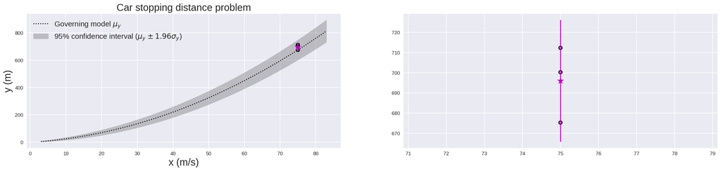

```python
# vvvvvvvvvvv this is just a trick so that we can run this cell multiple times vvvvvvvvvvv
fig_car_new, ax_car_new = plt.subplots(1,2); plt.close() # create figure and close it
if fig_car_new.get_axes():
    del ax_car_new; del fig_car_new # delete figure and axes if they exist
    fig_car_new, ax_car_new = plt.subplots(1,2) # create them again
# ^^^^^^^^^^^ end of the trick ^^^^^^^^^^^^^^^^^^^^^^^^^^^^^^^^^^^^^^^^^^^^^^^^^^^^^^^^^^^
N_samples = 3 # CHANGE THIS NUMBER AND RE-RUN THE CELL
x = 75; empirical_y = samples_y(N_samples,x); # Empirical measurements of N_samples
empirical_mu_y = np.mean(empirical_y); empirical_sigma_y = np.std(empirical_y); # empirical mean and std
car_fig(ax_car_new[0]) # a function I created to include the background plot of the governing model
for i in range(2): # create two plots (one is zooming in on the error bar)
    ax_car_new[i].errorbar(x , empirical_mu_y,yerr=1.96*empirical_sigma_y, fmt='*m', markersize=15);
    ax_car_new[i].scatter(x*np.ones_like(empirical_y),empirical_y, s=40,facecolors='none', edgecolors='k', linewidths=2.0)
print("Empirical mean[y] is",empirical_mu_y, "(real mean[y]=675)")
print("Empirical std[y] is",empirical_sigma_y,"(real std[y]=37.5)")
fig_car_new.set_size_inches(25, 5) # scale figure to be wider (since there are 2 subplots)
```

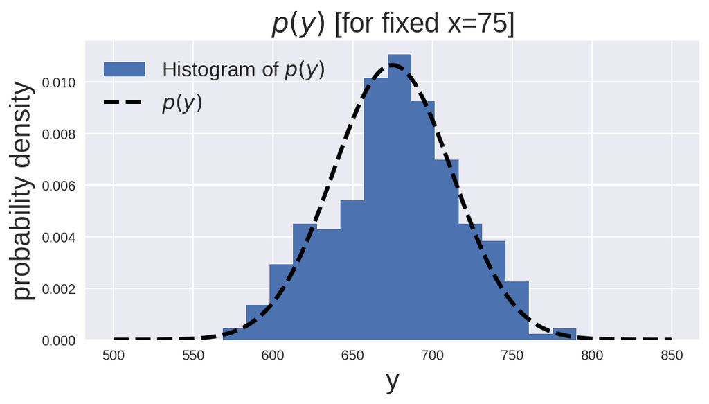

```python
fig_hist, ax_hist_y = plt.subplots()
# Plot the histogram obtained by sampling p(y) with data
empirical_y = samples_y(N_samples=300,x=75) # CHANGE NUMBER OF SAMPLES AND RE-RUN CELL
ax_hist_y.hist(empirical_y, bins='auto',
               density=True, label='Histogram of $p(y)$')
ax_hist_y.set_title("$p(y)$ [for fixed x=75]", fontsize=20)

# Plot the actual p(y|z) pdf:
yrange = np.linspace(500, 850, 200) # to show the real Gaussian distribution
ax_hist_y.plot(yrange, norm.pdf(yrange, 675, 37.5), 'k--', linewidth = 3, label='$p(y)$')
ax_hist_y.set_xlabel("y", fontsize=20)
ax_hist_y.set_ylabel("probability density", fontsize=20)
ax_hist_y.legend(fontsize=15, loc='upper left');
```

## Conclusions about $y$ and $z$

- We conclude that $y$ is also an rv because $z$ is an rv.
- In this case, we empirically found that $p(y)$ is also a Gaussian distribution, just like $z$ but with different parameters. This makes sense because $y$ is just linearly dependent on $z$.
- Also recall that in **Exercise 2** from Lecture 2 we calculated the expected value (mean) and variance of $y$.

These observations lead to the conclusion:

$$ p(y) = \mathcal{N}(\mu_{y}=675,\sigma_{y}^2=37.5^2) $$

with $p(z) = \mathcal{N}(\mu_z=1.5,\sigma_z^2=0.5^2)$ and for $x=75$.

## Transformation of random variables

This empirical conclusion can be reached analytically from the **change of variables formula**.

This formula says that if $y=f(z)$ and if this function is invertible, i.e. $z=f^{-1}(y)=g(y)$, then:

$$ p_y(y) = p_z\left( g(y) \right) \left| \frac{d}{dy}g(y)\right| $$

where $g(y) = f^{-1}(z)$.

### Exercise 1

Use the change of variables formula to demonstrate that $p(y)$ is a Gaussian distribution with the expected value and variance determined in Lecture 2 (Exercise 2). In other words, that $p(y)=\mathcal{N}(y|\mu_{y}=x\mu_z+0.1x^2, \sigma_y^2 = \sigma_z^2 x^2)$ when $y=x z + 0.1x^2$.

## Introducing joint probability density of $y$ and $z$

Just like in Lecture 1 where we talked about **joint probability** of two events, $\text{Pr}(A \wedge B)= \text{Pr}(A, B)$, the **joint probability density** is:

$$ p(y \wedge z)= p(y, z) $$

- But how do we **calculate** $p(y,z)$?

**If** the two rv's were independent, then it would be: $p(y,z)=p(y)p(z)$

**But...** We know that $y$ is dependent on $z$... So now what do we do?

## What is the joint probability density of $y$ and $z$?

As we saw in Lecture 1,

$$ p(y, z) = p(y|z)p(z) = p(z|y)p(y) = p(z, y) $$

Here, we already know $p(y)$ and $p(z)$.

- But what is the **conditional pdf** $p(y|z)$? Tell me what you think!

## What is the joint probability density of $y$ and $z$?

Since $y$ and $z$ are dependent, the joint pdf $p(y,z)$ is

$$ p(y, z) = \delta\left(y-(z x+0.1x^2)\right) p(z) $$

where $p(y|z)=\delta\left(y-(z x+0.1x^2)\right)$ is the Dirac delta pdf, assigning zero probability everywhere except when $y=z x+0.1x^2$.

Recall that $p(z) = \mathcal{N}(\mu_z=1.5,\sigma_z^2=0.5^2)$ (for now you can also forget about $x$ since $x=75$).

- Note: $p(y,z)$ and $p(y|z)$ are pdf's that depend on *both* $y$ and $z$, but the joint pdf $p(y,z)$ has two rv's while the conditional pdf $p(y|z)$ has $z$ conditioned to a value (it's like "removing" the stochasticity of $z$).

## Why do we care about joint pdfs?

In general, from a joint pdf $p(y,z)$ we can obtain $p(y)$ and $p(z)$ simply by **integrating out** wrt the other variable. This is called **marginalizing**:

$$ p(y) = \int p(y,z) dz $$$$ p(z) = \int p(y,z) dy $$

Therefore, $p(y)$ and $p(z)$ are also called **marginal distributions** of $p(y,z)$.

### Exercise 2

Knowing that $p(y, z) = \delta\left(y-(z x+0.1x^2)\right) \mathcal{N}(z|\mu_z,\sigma_z^2)$, calculate $p(y)$ and $p(z)$.

## In general, do we know the true conditional distribution $p(y|z)$?

Unfortunately, we usually don't know the true conditional pdf $p(y|z)$ because $z$ is hidden!

(Remember: we are cheating with the *car stopping distance problem* because we already know that $y=zx+0.1x^2$)

In general, we don't know the true relationship between $y$ and $z$...

- So, what can we do?

We can **observe** the effect caused by the hidden $z$ in $y$ by taking measurements of $y$.

In other words, within the measurements of $y$ (which we call data $\mathcal{D}_y$) lies the *effect* of the hidden $z$.

- The Bayes' rule provides a way to estimate the distribution of the hidden rv $z$ given data $\mathcal{D}_y$.

## Remember the amazing Bayes' rule

Bayes’ rule: a formula for computing the probability distribution over possible values of an unknown (or hidden) quantity $z$ given some observed data $y$:

$$ p(z|y) = \frac{p(y|z) p(z)}{p(y)} $$

Bayes' rule follows automatically from the identity: $p(z|y) p(y) = p(y|z) p(z) = p(y,z) = p(z,y)$

## Bayes' rule

$\require{color}$ The pdfs we have been discussing in this lecture are what enable us to create ML models via the Bayes' rule when we apply it on **observed data** $\mathcal{D}_y$:

$$ {\color{green}p(z|y=\mathcal{D}_y)} = \frac{ {\color{blue}p(y=\mathcal{D}_y|z)}{\color{red}p(z)} } {p(y=\mathcal{D}_y)} $$

- ${\color{red}p(z)}$ is the **prior** distribution: this term represents what we know (or what we believe we know!) about possible values of the unknown (hidden) rv $z$ before we see any data.

## Bayes' rule

$\require{color}$ The pdfs we have been discussing in this lecture are what enable us to create ML models via the Bayes' rule when we apply it on **observed data** $\mathcal{D}_y$:

$$ {\color{green}p(z|y=\mathcal{D}_y)} = \frac{ {\color{blue}p(y=\mathcal{D}_y|z)}{\color{red}p(z)} } {p(y=\mathcal{D}_y)} $$

- $\require{color}{\color{blue}p(y | z)}$ is the **observation** distribution (not yet the likelihood!): represents the distribution over the possible outcomes $y$ we expect to see given a particular hidden variable $z$.
  - When we evaluate the observation distribution $p(y | z)$ at a point corresponding to the actual observations, $y=\mathcal{D}_y$, we get the function $p(y=\mathcal{D}_y|z)$:
    - ${\color{blue}p(y=\mathcal{D}_y|z)}$ is the **likelihood** function: it is a function of $z$, since $y$ is *fixed* to the observations $\mathcal{D}_y$, but **it is not a probability distribution** (it does not sum to one).

## Bayes' rule

$\require{color}$ The pdfs we have been discussing in this lecture are what enable us to create ML models via the Bayes' rule when we apply it on **observed data** $\mathcal{D}_y$:

$$ {\color{green}p(z|y=\mathcal{D}_y)} = \frac{ {\color{blue}p(y=\mathcal{D}_y|z)}{\color{red}p(z)} } {p(y=\mathcal{D}_y)} $$

- $p(y=\mathcal{D}_y)$ is the **marginal likelihood**, which is obtained by *marginalizing* over the unknown $z$.

## Bayes' rule

$\require{color}$ The pdfs we have been discussing in this lecture are what enable us to create ML models via the Bayes' rule when we apply it on **observed data** $\mathcal{D}_y$:

$$ {\color{green}p(z|y=\mathcal{D}_y)} = \frac{ {\color{blue}p(y=\mathcal{D}_y|z)}{\color{red}p(z)} } {p(y=\mathcal{D}_y)} $$

- ${\color{green}p(z|y=\mathcal{D}_y)}$ is the **posterior**, which represents our *belief state* about the possible values of the unknown $z$.

## Summary of Bayes' rule

$\require{color}$ $$ {\color{green}p(z|y=\mathcal{D}_y)} = \frac{ {\color{blue}p(y=\mathcal{D}_y|z)}{\color{red}p(z)} } {p(y=\mathcal{D}_y)} = \frac{ {\color{magenta}p(y=\mathcal{D}_y, z)} } {p(y=\mathcal{D}_y)} $$

- ${\color{red}p(z)}$ is the **prior** distribution
- ${\color{blue}p(y=\mathcal{D}_y|z)}$ is the **likelihood** function
- ${\color{magenta}p(y=\mathcal{D}_y, z)}$ is the **joint likelihood** (product of likelihood function with prior distribution)
- $p(y=\mathcal{D}_y)$ is the **marginal likelihood**
- ${\color{green}p(z|y=\mathcal{D}_y)}$ is the **posterior**

We can write Bayes' rule as posterior $\propto$ likelihood $\times$ prior , where we are ignoring the denominator $p(y=\mathcal{D}_y)$ because it is just a **constant** independent of the hidden variable $z$.

### See you next class

Have fun!